# predict() function in mixed models

### **NOTES ON STATISTICS, PROBABILITY and MATHEMATICS**

### `predict()` in Mixed-Effects Model:

I posted this [question on CV](http://stats.stackexchange.com/q/174203/67822) here.

**The problem:**

I have read in other [posts (a bit old)](http://stats.stackexchange.com/a/4202/67822) that `predict` is not available for mixed effects `lmer` {lme4} models in [R]. **EDIT**: Although I know now, thanks to @EdM, that this exists in more recent versions, the question still is unresolved in terms of the actual algebra from $intercepts$ and $slopes$ `->` $predicted$ values.

However, in trying to get a more plastic sense of linear effects, I came across a situation where the `predict` call did seem to incorporate the random effects in the model, yielding a plausible output.

**Background:**

I’m working with an extremely massaged toy dataset. For the sake of intellectual honesty, I think I got the idea of the set from a Princeton on-line class, but any similarity to the original is at this point coincidental. In unsuccessfully looking for the original, I did come across [this](http://data.princeton.edu/wws509/datasets/) that can serve as indirect credit and much more.

If anybody is so inclined to take a look directly it can be retrieved directly:

```
require(gsheet)
data <- read.csv(text =
     gsheet2text('https://docs.google.com/spreadsheets/d/1QgtDcGJebyfW7TJsB8n6rAmsyAnlz1xkT3RuPFICTdk/edit?usp=sharing',
        format ='csv'))
head(data)

  Subject Auditorium Education Time  Emotion Caffeine Recall
1     Jim          A        HS    0 Negative       95 125.80
2     Jim          A        HS    0  Neutral       86 123.60
3     Jim          A        HS    0 Positive      180 204.00
```

So we have some repeated observations (`Time`) of a continuous measurement of the `Recall` rate of some words, and several $\small DV$’s, including random effects (`Auditorium` where the test took place; `Subject` name); and explanatory or fixed effects, such as `Education`, `Emotion` (the emotional connotation of the word to remember), or $\small mgs.$ of `Caffeine` ingested prior to the test.

The idea is that it’s easy to remember for hyper-caffeinated wired subjects, but the ability decreases over time, perhaps due to tiredness. Words with negative connotation are more difficult to remember. Education has an effect that is intuitive, and “surprisingly” the Auditorium also plays a role (perhaps one was more noisy, or less comfortable). Here’re a couple of exploratory plots:

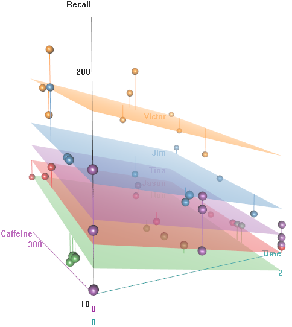

I know… so cool… Have you noticed that Tina doesn’t drink coffee? How can anybody spend the night on CV, and be able to function in the morning without coffee?

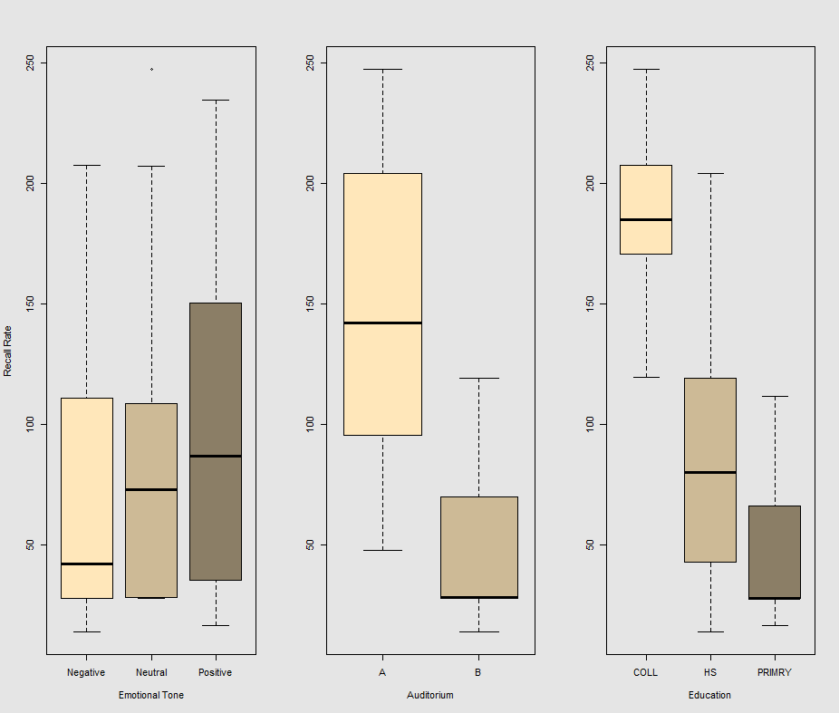

**The issue:**

When fitting lines on the data cloud for the call:

`fit1 <- lmer(Recall ~ (1|Subject) + Caffeine, data = data)`

I get this plot:

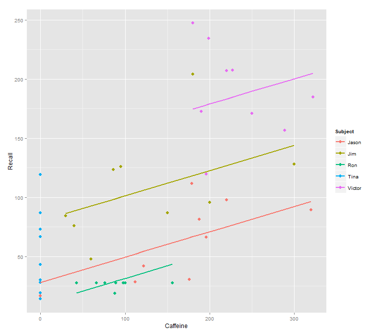

with the following code (notice the call for $\small predict(fit1)$) in it:

```
library(ggplot2)
p <- ggplot(data, aes(x = Caffeine, y = Recall, colour = Subject)) +
  geom_point(size=3) +
  geom_line(aes(y = predict(fit1)),size=1)
print(p)
```

while the following model:

`fit2 <- lmer(Recall ~ (1|Subject/Time) + Caffeine, data = data)`

incorporating `Time` and a parallel code gets a surprising plot:

```
p <- ggplot(data, aes(x = Caffeine, y = Recall, colour = Subject)) +
  geom_point(size=3) +
  geom_line(aes(y = predict(fit2)),size=1)
print(p)
```

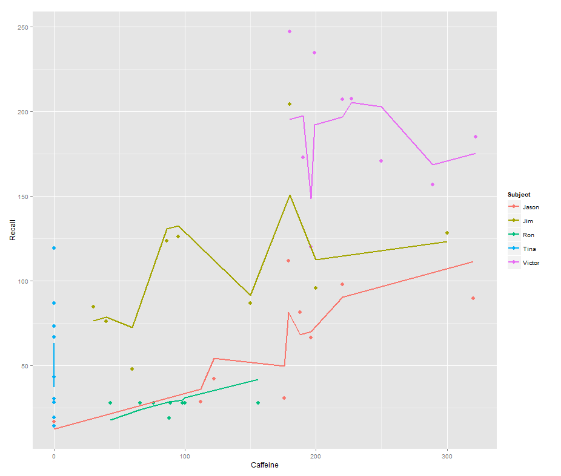

**The question:**

**How does the `predict` function operate in this `lmer` model?** Evidently it’s taking into consideration the `Time` variable, resulting in a much tighter fit, and the zig-zagging that is trying to display this third dimension of `Time` portrayed in the first plot.

If I call `predict(fit2)` I get `132.45609` for the first entry, which corresponds to the first point: `Subject = Jim`, `Auditorium = A`, `Education = HS`, `Time = 0`, `Emotion = Negative`, `Caffeine = 95` and `Recall = 125.8`

The coefficients for `fit2` are:

```
$`Time:Subject`
         (Intercept)  Caffeine
0:Jason     75.03040 0.2116271
0:Jim       94.96442 0.2116271
0:Ron       58.72037 0.2116271
0:Tina      70.81225 0.2116271
0:Victor    86.31101 0.2116271
1:Jason     59.85016 0.2116271
1:Jim       52.65793 0.2116271
1:Ron       57.48987 0.2116271
1:Tina      68.43393 0.2116271
1:Victor    79.18386 0.2116271
2:Jason     43.71483 0.2116271
2:Jim       42.08250 0.2116271
2:Ron       58.44521 0.2116271
2:Tina      44.73748 0.2116271
2:Victor    36.33979 0.2116271

$Subject
       (Intercept)  Caffeine
Jason     30.40435 0.2116271
Jim       79.30537 0.2116271
Ron       13.06175 0.2116271
Tina      54.12216 0.2116271
Victor   132.69770 0.2116271
```

My best bet was `94.96442 + 0.2116271 * 95 = 115.0689945`… Not too far off, but wrong. **What is the formula to get instead to `132.45609`?**

### THE ANSWER:

It’s easy to get confused by the presentation of coefficients when you call `coef(fit2)`. Look at the summary of fit2:

> ```
> > summary(fit2)
> ```

> Linear mixed model fit by REML [‘lmerMod’] Formula: Recall ~ (1 | Subject/Time) + Caffeine Data: data

```
REML criterion at convergence: 444.5

Scaled residuals:
 Min       1Q   Median       3Q      Max
-1.88657 -0.46382 -0.06054  0.31430  2.16244

Random effects:
 Groups       Name        Variance Std.Dev.
 Time:Subject (Intercept)  558.4   23.63
 Subject      (Intercept) 2458.0   49.58
 Residual                  675.0   25.98
Number of obs: 45, groups:  Time:Subject, 15; Subject, 5

Fixed effects:
Estimate Std. Error t value
(Intercept) 61.91827   25.04930   2.472
Caffeine     0.21163    0.07439   2.845

Correlation of Fixed Effects:
 (Intr)
Caffeine -0.365
```

Instead of using `coef`, use `ranef` to get the difference of each random-effect intercept from the mean intercept at the next higher level of nesting:

> ```
> > ranef(fit2)
> ```

> $`Time:Subject` (Intercept) 0:Jason 13.112130 0:Jim 33.046151 0:Ron -3.197895 0:Tina 8.893985 0:Victor 24.392738 1:Jason -2.068105 1:Jim -9.260334 1:Ron -4.428399 1:Tina 6.515667 1:Victor 17.265589 2:Jason -18.203436 2:Jim -19.835771 2:Ron -3.473053 2:Tina -17.180791 2:Victor -25.578477

```
$Subject
       (Intercept)
Jason   -31.513915
Jim      17.387103
Ron     -48.856516
Tina     -7.796104
Victor   70.779432
```

The intercept values returned by `coef` seem to represent the overall intercept plus the `Subject` or `Time:Subject` specific differences, so it’s harder to work with those; if you tried to do the above calculation with the `coef` values you would be double-counting the overall intercept.

[Home Page](http://rinterested.github.io/statistics/index.html)

**NOTE: These are tentative notes on different topics for personal use - expect mistakes and misunderstandings.**